# Does Scandal Coverage Change What Trump Talks About?

Lucian Scher

2026-06-09

## The question

This post follows my assignment for the MEDS course *EDS 231: Text Sentiment Analysis* taught by Mateo Robbins. It is meant as a practice and exploration of text sentiment methods. It is meant for purely academic purposes, in no way am I claiming scientific accuracy or causality.

I started with a pretty familiar worry about the news cycle: when scandal and conflict take over, climate and environment stuff gets pushed to the margins. Does that show up in what Trump *says*, not just what gets written about him?

The narrowed version of that question for this project: in weeks when the *New York Times* is running a lot of **damaging** Trump coverage, does his speech lean more **conflict** and less **environmental** in the same stretch of time?

I’m comparing Senate Democrats speech transcripts against NYT Article Search hits for `q = "trump"`. Nothing here is causal — I’m looking for patterns in the same weeks, not claiming Trump is “strategically distracting” because a line went up on a chart.

## Setup and data window

```r
library(tidyverse)
library(tidytext)
library(lubridate)
library(scales)
library(quanteda)
library(quanteda.textstats)
library(topicmodels)
library(ggrepel)
```

```r
# Shared colors and ggplot theme for all figures
col_dark   <- "#1F2729"
col_accent <- "#64D297"
col_light  <- "#F9FAFD"

plot_font <- if ("Proxima Nova" %in% systemfonts::system_fonts()$family) {
  "Proxima Nova"
} else {
  "Helvetica"
}

theme_project <- function() {
  theme_minimal(base_family = plot_font, base_size = 12) +
    theme(
      plot.background  = element_rect(fill = col_light, color = NA),
      panel.background = element_rect(fill = col_light, color = NA),
      panel.grid.minor = element_blank(),
      text             = element_text(color = col_dark),
      plot.title       = element_text(face = "bold", color = col_dark),
      plot.subtitle    = element_text(color = col_dark),
      axis.text        = element_text(color = col_dark),
      legend.position  = "bottom"
    )
}

cols_source <- c("NYT" = col_dark, "Trump" = col_accent)
```

The two corpora don’t line up perfectly on time. NYT collection ran through the Article Search API in two-week chunks (Lab 1 workflow) until the API started returning **HTTP 429** rate-limit errors. That capped news coverage at late September. Speeches keep going well beyond that.

[output not shown]

Everything downstream uses the overlap window unless noted otherwise.

## Building the speech corpus

```r
# Read full corpus and split on the 80-char divider between transcripts
raw <- paste(readLines("data/speeches/corpus.txt"), collapse = "\n")
chunks <- str_split(raw, "─{80}")[[1]]
chunks <- chunks[str_trim(chunks) != ""]

parse_transcript <- function(chunk) {
  title <- str_match(chunk, "=== (.+?) \\|")[, 2]
  url   <- str_match(chunk, "(https://[^\\n]+)")[, 2]
  body  <- str_trim(str_replace(chunk, ".*https://[^\\n]+\\n", ""))
  tibble(title, url, body)
}

# Dates are in the title suffix (M.D.YY), not the metadata field
parse_title_date <- function(title) {
  m <- str_match(title, "(\\d{1,2})\\.(\\d{1,2})\\.(\\d{2})$")
  if (is.na(m[1, 1])) return(as.Date(NA))
  y <- as.integer(m[1, 4])
  y <- if (y < 70) 2000 + y else 1900 + y
  make_date(y, as.integer(m[1, 2]), as.integer(m[1, 3]))
}

clean_text <- function(text) {
  text |>
    str_remove_all("\\[.*?\\]") |>
    str_replace_all("\n", " ") |>
    str_squish()
}

# Keep only lines spoken by Trump (transcripts include reporters/Q&A)
trump_only <- function(text) {
  hits <- str_extract_all(
    text,
    "(?<=(?:President Trump|Donald Trump|Trump):\\s{0,5})[^\\n]+"
  )[[1]]
  paste(hits, collapse = " ")
}

speech_df <- map_dfr(chunks, parse_transcript) |>
  mutate(
    date       = as.Date(sapply(title, parse_title_date), origin = "1970-01-01"),
    year_month = floor_date(date, "month"),
    week       = floor_date(date, "week"),
    doc_id     = row_number(),
    body_clean = clean_text(body),
    body_trump = map_chr(body_clean, trump_only),
    word_count = str_count(body_trump, "\\S+"),
    source     = "speech"
  )

speech_df |> select(title, date, word_count) |> head()
```

```
## # A tibble: 6 × 3
##   title                                                    date       word_count
##   <chr>                                                    <date>          <int>
## 1 TRANSCRIPT: President Trump Delivers the Commencement A… 2026-05-20      24003
## 2 TRANSCRIPT: President Trump Speaks to Reporters Before … 2026-05-20       6150
## 3 TRANSCRIPT: President Trump Attends the Congressional P… 2026-05-19      10439
## 4 TRANSCRIPT: President Trump Walks Reporters Through Whi… 2026-05-19      20985
## 5 TRANSCRIPT: President Trump Attends a White House Healt… 2026-05-18      16940
## 6 TRANSCRIPT: President Trump Vlog: Ed Gallrein Endorseme… 2026-05-18        551
```

Transcripts come from a single `corpus.txt` file scraped from the Senate Democrats newsroom. Each entry is split on the long divider line, then parsed for title, URL, and body text.

The part that took some debugging: dates live in the title suffix (`5.20.26` style), not in the metadata field that says `unknown`. I also strip stage directions like `[inaudible]` and pull only lines attributed to Trump — the raw transcript has reporters and other speakers mixed in, and that’s not what I’m trying to measure.

## NYT articles

```r
# Each cached RDS file = one API page from a 2-week fetch window
nyt_files <- list.files(
  "data/nyt/nyt_cache",
  pattern = "^trump_.*\\.rds$",
  full.names = TRUE
)

nyt_df <- map_dfr(nyt_files, readRDS) |>
  distinct(web_url, .keep_all = TRUE) |>  # drop duplicate URLs across pages
  mutate(
    date       = as.Date(created_time),
    year_month = floor_date(date, "month"),
    week       = floor_date(date, "week"),
    text       = paste(headline, snippet),  # API gives snippet, not full article
    word_count = str_count(text, "\\S+"),
    source     = "nyt",
    doc_id     = row_number()
  )

nyt_df |> select(headline, date) |> head()
```

```
##                                                                     headline
## 1        For Trump, Domestic Adversaries Are Not Just Wrong, They Are ‘Evil’
## 2                              Trump Pledges to Send More Weapons to Ukraine
## 3                 The ‘Trump Pump’: How Crypto Lobbying Won Over a President
## 4           Rising Inflation Underscores Risks in Trump’s New Tariff Threats
## 5 As Trump Sows Tariff Confusion, Rules of Global Commerce Give Way to Chaos
## 6                       Inside the Long Friendship Between Trump and Epstein
##         date
## 1 2025-07-16
## 2 2025-07-08
## 3 2025-07-09
## 4 2025-07-15
## 5 2025-07-11
## 6 2025-07-19
```

```r
# Only weeks where both NYT and speech data exist
overlap_start <- as.Date("2025-07-07")
overlap_end   <- as.Date("2025-09-28")

speech_overlap <- speech_df |> filter(date >= overlap_start, date <= overlap_end)
nyt_overlap    <- nyt_df |> filter(date >= overlap_start, date <= overlap_end)
```

```r
knitr::kable(
  tibble(
    metric = c(
      "Speeches (all)", "Speeches (overlap)",
      "NYT articles (all)", "NYT articles (overlap)",
      "NYT dates", "Speech dates"
    ),
    value = c(
      nrow(speech_df), nrow(speech_overlap),
      nrow(nyt_df), nrow(nyt_overlap),
      paste(min(nyt_df$date), "to", max(nyt_df$date)),
      paste(min(speech_df$date, na.rm = TRUE), "to", max(speech_df$date, na.rm = TRUE))
    )
  ),
  caption = "Data validation"
)
```

Data validation

| metric | value |
| --- | --- |
| Speeches (all) | 419 |
| Speeches (overlap) | 67 |
| NYT articles (all) | 4578 |
| NYT articles (overlap) | 4578 |
| NYT dates | 2025-07-07 to 2025-09-28 |
| Speech dates | 2025-07-08 to 2026-05-20 |

NYT rows are built from cached API pulls — headline plus snippet, not full article text. (The Search API doesn’t hand you the body; Lab 1 works the same way.) After deduping on URL, the counts in the table above are what actually enter the analysis.

## Defining “damaging,” “conflict,” and “environmental”

Professor feedback pushed me to be explicit about operational definitions instead of waving at “scandal coverage” in the abstract. I landed on three keyword lists. They’re blunt, and I tried to say that out loud rather than pretend they’re objective.

```r
# Keyword lists for operationalizing themes (counts per 1,000 words)
conflict_words <- c(
  "war", "iran", "strike", "military", "nuclear", "bomb",
  "invasion", "missile", "enemy", "attack", "troops"
)
damage_words <- c(
  "epstein", "scandal", "indictment", "lawsuit", "trial",
  "conviction", "jury", "deposition", "investigation"
)
env_words <- c(
  "climate", "environment", "epa", "emissions", "carbon",
  "renewable", "conservation", "pollution", "green"
)

dict_tbl <- bind_rows(
  tibble(category = "Conflict / explosive", term = conflict_words),
  tibble(category = "Damaging coverage",    term = damage_words),
  tibble(category = "Environmental",        term = env_words)
)

knitr::kable(dict_tbl, caption = "Keyword dictionaries (operational definitions)")
```

Keyword dictionaries (operational definitions)

| category | term |
| --- | --- |
| Conflict / explosive | war |
| Conflict / explosive | iran |
| Conflict / explosive | strike |
| Conflict / explosive | military |
| Conflict / explosive | nuclear |
| Conflict / explosive | bomb |
| Conflict / explosive | invasion |
| Conflict / explosive | missile |
| Conflict / explosive | enemy |
| Conflict / explosive | attack |
| Conflict / explosive | troops |
| Damaging coverage | epstein |
| Damaging coverage | scandal |
| Damaging coverage | indictment |
| Damaging coverage | lawsuit |
| Damaging coverage | trial |
| Damaging coverage | conviction |
| Damaging coverage | jury |
| Damaging coverage | deposition |
| Damaging coverage | investigation |
| Environmental | climate |
| Environmental | environment |
| Environmental | epa |
| Environmental | emissions |
| Environmental | carbon |
| Environmental | renewable |
| Environmental | conservation |
| Environmental | pollution |
| Environmental | green |

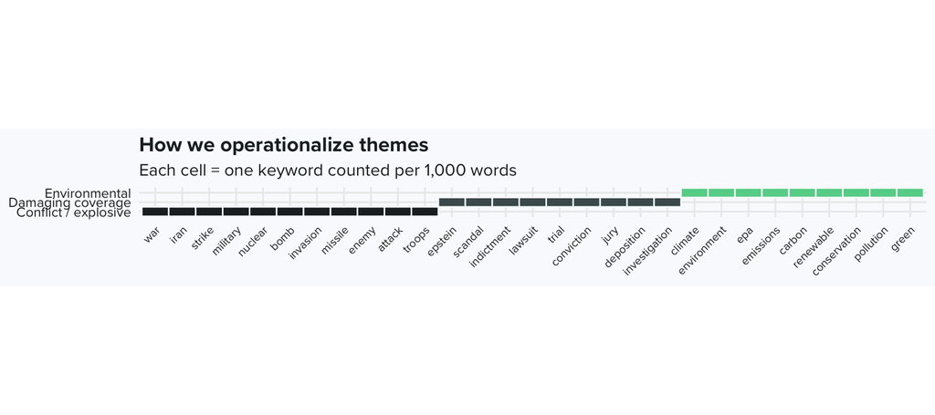

```r
dict_tbl |>
  mutate(term = fct_inorder(term)) |>
  ggplot(aes(term, category, fill = category)) +
  geom_tile(color = col_light, linewidth = 0.5) +
  scale_fill_manual(
    values = c(
      "Conflict / explosive" = col_dark,
      "Damaging coverage" = "#4a5a5e",
      "Environmental" = col_accent
    )
  ) +
  coord_fixed(ratio = 0.35) +
  labs(
    title = "How we operationalize themes",
    subtitle = "Each cell = one keyword counted per 1,000 words",
    x = NULL, y = NULL, fill = NULL
  ) +
  theme_project() +
  theme(
    axis.text.x = element_text(angle = 45, hjust = 1, size = 8),
    legend.position = "none"
  )
```

**Conflict** covers war-and-strike language (iran, military, nuclear, etc.). **Damaging** is legal/scandal framing (epstein, indictment, lawsuit…). **Environmental** is the climate bucket (epa, emissions, carbon…). I left out `ice` on purpose — in this corpus it shows up for icebreakers and immigration, not one clear theme.

For keyness and LDA I also built stopword layers on top of the SMART list from Lab 2: news boilerplate, transcript filler (`uh`, `um`, applause), and a batch of place/name tokens that otherwise dominate the frequency tables without telling us much about the research question.

```r
# Lab 2 pattern: SMART + domain + transcript noise (letters-only keeps punctuation out)
smart_sw <- get_stopwords(source = "smart")$word

domain_sw <- c(
  "said", "says", "told", "according", "reported", "noted", "added",
  "stated", "announced", "mr", "ms", "inc", "corp", "llc",
  "president", "trump", "donald", "white", "house",
  "united", "states", "america", "american", "people", "country",
  "think", "going", "know", "well", "right", "just", "like",
  "year", "years", "percent", "million", "billion", "quarter",
  "company", "companies", "firm", "business", "news", "times"
)

transcript_sw <- c(
  "inaudible", "laughter", "applause", "crosstalk", "uh", "um", "huh",
  "sir", "okay", "yeah", "gonna", "want", "got", "thank", "thanks",
  "yes", "no", "one", "two", "three"
)

# Frequent place / person tokens in this corpus (Lab 2 domain list extension)
geo_names_sw <- c(
  "china", "iran", "israel", "ukraine", "russia", "gaza", "europe",
  "biden", "harris", "obama", "musk", "zelensky", "netanyahu", "putin",
  "washington", "york", "california", "texas", "florida", "mexico",
  "canada", "london", "beijing", "moscow", "jerusalem", "india", "japan",
  "korea", "afghanistan", "iraq", "syria", "venezuela", "greenland"
)

all_sw <- unique(c(smart_sw, domain_sw, transcript_sw, geo_names_sw))

knitr::kable(
  tibble(
    list = c("SMART (Lab 2)", "Domain / news", "Transcript noise", "Places & names"),
    n_terms = c(
      length(smart_sw), length(domain_sw),
      length(transcript_sw), length(geo_names_sw)
    ),
    example = c(
      "the, and, of",
      "said, reported, trump",
      "uh, um, applause",
      "iran, china, biden"
    )
  ),
  caption = "Stopword layers applied before keyness and LDA"
)
```

Stopword layers applied before keyness and LDA

| list | n_terms | example |
| --- | --- | --- |
| SMART (Lab 2) | 571 | the, and, of |
| Domain / news | 44 | said, reported, trump |
| Transcript noise | 20 | uh, um, applause |
| Places & names | 33 | iran, china, biden |

```r
dict_rate <- function(text, dict) {
  # Share of words in `dict` per 1,000 tokens
  if (!nzchar(text)) return(0)
  words <- str_extract_all(tolower(text), "[a-z]+")[[1]]
  if (length(words) == 0) return(0)
  sum(words %in% dict) / length(words) * 1000
}
```

“High-damage weeks” are the top quartile of weeks ranked by how many NYT articles hit at least one damaging keyword. I use that cut for the keyness target group — speeches from those weeks vs. everything else in the overlap.

```r
# Flag weeks in top quartile of NYT articles hitting damage keywords
nyt_week_damage <- nyt_overlap |>
  mutate(dmg = map_lgl(text, ~ dict_rate(.x, damage_words) > 0)) |>
  group_by(week) |>
  summarise(damage_docs = sum(dmg), nyt_articles = n(), .groups = "drop")

damage_cut <- quantile(nyt_week_damage$damage_docs, 0.75, na.rm = TRUE)
high_weeks <- nyt_week_damage |>
  filter(damage_docs >= damage_cut) |>
  pull(week)

knitr::kable(
  nyt_week_damage |>
    mutate(high_damage_week = week %in% high_weeks) |>
    arrange(week),
  caption = paste0(
    "Weekly NYT damaging coverage (cutoff = ", damage_cut,
    " articles with damage terms)"
  )
)
```

Weekly NYT damaging coverage (cutoff = 28 articles with damage terms)

| week | damage_docs | nyt_articles | high_damage_week |
| --- | --- | --- | --- |
| 2025-07-06 | 14 | 336 | FALSE |
| 2025-07-13 | 43 | 389 | TRUE |
| 2025-07-20 | 49 | 371 | TRUE |
| 2025-07-27 | 21 | 381 | FALSE |
| 2025-08-03 | 18 | 362 | FALSE |
| 2025-08-10 | 9 | 371 | FALSE |
| 2025-08-17 | 21 | 374 | FALSE |
| 2025-08-24 | 12 | 332 | FALSE |
| 2025-08-31 | 19 | 325 | FALSE |
| 2025-09-07 | 28 | 399 | TRUE |
| 2025-09-14 | 11 | 445 | FALSE |
| 2025-09-21 | 28 | 459 | TRUE |
| 2025-09-28 | 1 | 34 | FALSE |

## How much data do we actually have?

The coverage plot is worth a look before interpreting anything else. NYT volume is steady through the summer and then stops cold at the dashed line — that’s the rate limit, not a lack of news. Trump speeches keep showing up for months after that, but those later transcripts can’t be paired with NYT in this project.

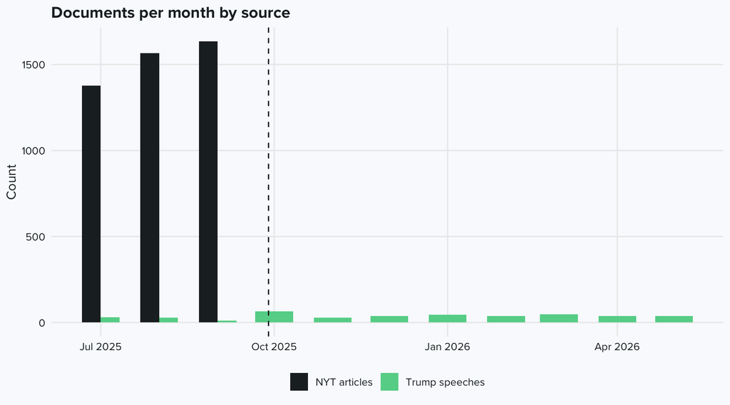

```r
bind_rows(
  speech_df |> mutate(source = "Trump speeches"),
  nyt_df |> mutate(source = "NYT articles")
) |>
  filter(!is.na(date)) |>
  mutate(month = floor_date(date, "month")) |>
  count(month, source) |>
  ggplot(aes(month, n, fill = source)) +
  geom_col(position = "dodge", width = 20) +
  geom_vline(xintercept = overlap_end, linetype = "dashed", color = col_dark) +
  scale_fill_manual(values = c("NYT articles" = col_dark, "Trump speeches" = col_accent)) +
  scale_x_date(date_labels = "%b %Y") +
  labs(title = "Documents per month by source", x = NULL, y = "Count", fill = NULL) +
  theme_project()
```